# Grande Barco Inafundavel que Afundou

2023-03-09

## Objetivo da Análise

O objetivo da análise é investigar e compreender o perfil dos passageiros e **explorar as características que podem ter influenciado as chances de sobrevivência dos passageiros**. A fonte dos dados utilizados pode variar, mas algumas das mais comuns são os registros oficiais dos passageiros do Titanic disponíveis publicamente, como os fornecidos pelo site Kaggle https://www.kaggle.com/c/titanic/data e pelo Museu Marítimo Nacional dos EUA https://www.maritime.org/titanic/passengers.htm.

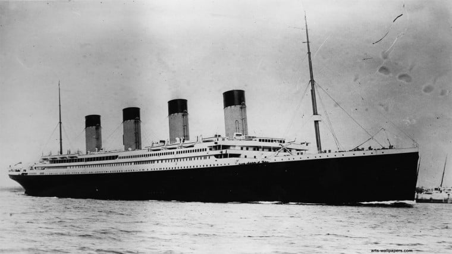

titanic

## Bibliotecas e Dataframe

```r
if(!require(tidyverse)) install.packages('tidyverse');library(tidyverse)
```

```r
if(!require(ggplot2)) install.packages('ggplot2');library(ggplot2)
if(!require(dplyr)) install.packages('dplyr');library(dplyr)
if(!require(ggcorrplot)) install.packages('ggcorrplot');library(ggcorrplot)
if(!require(scales)) install.packages('scales');library(scales)
if(!require(stringr)) install.packages('stringr');library(stringr)

df <- read.csv('data/titanic.csv') # Variável principal `Survived
```

## Correlação e Componentes Principais

**Visualização dos atributos e suas correlaçõe**

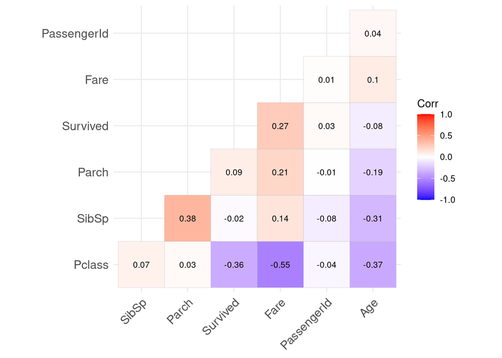

```r
# Seleciona apenas as variáveis numéricas e remove linhas com valores faltantes
df %>%
  select_if(is.numeric) %>%  # seleciona apenas as variáveis numéricas
  na.omit() %>%  # remove as linhas com valores faltantes
  cor() %>%  # calcula a correlação entre as variáveis
  ggcorrplot(lab = TRUE, lab_size = 3, hc.order = TRUE, type = "lower")  # cria o gráfico
```

```r
# Seleciona as variáveis numéricas relevantes, cria uma variável binária para o gênero e remove linhas com valores faltantes
df_pca <- df %>%
  mutate(Genere = ifelse(Sex == 'female', 1, 0 )) %>%  # cria uma variável binária para o gênero
  select(Survived, Pclass, Genere, Age, SibSp, Parch, Fare) %>%  # seleciona as variáveis numéricas relevantes
  drop_na()  # remove as linhas com valores faltantes

# Normaliza os dados e executa o PCA
df_pca_norm <- apply(df_pca, 2, scale)  # normaliza os dados excluindo a primeira coluna (Survived)
pca <- prcomp(df_pca_norm)  # realiza o PCA

# Exibe informações sobre as componentes principais
summary(pca)
```

```
## Importance of components:
##                           PC1    PC2    PC3    PC4     PC5     PC6     PC7
## Standard deviation     1.4573 1.3179 1.0561 0.8467 0.75108 0.65490 0.56059
## Proportion of Variance 0.3034 0.2481 0.1593 0.1024 0.08059 0.06127 0.04489
## Cumulative Proportion  0.3034 0.5515 0.7108 0.8133 0.89384 0.95511 1.00000
```

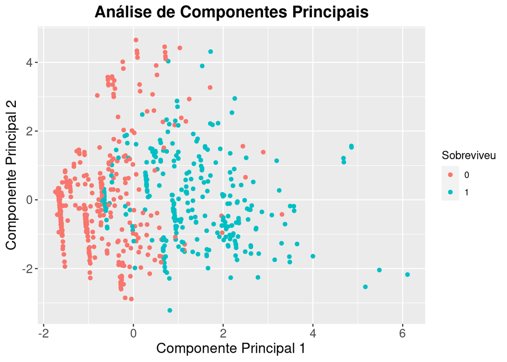

```r
# Cria um dataframe com as duas primeiras componentes principais e adiciona a variável 'Survived'
df_pca_plot <- as.data.frame(pca$x[, 1:2])  # extrai as duas primeiras componentes principais
df_pca_plot$Survived <- df_pca$Survived  # adiciona a variável 'Survived'

# Cria o gráfico de dispersão das componentes principais
ggplot(df_pca_plot, aes(x = PC1, y = PC2, color = factor(Survived))) +  # define as variáveis a serem plotadas
  geom_point() +  # adiciona os pontos
  labs(title = "Análise de Componentes Principais", x = "Componente Principal 1", y = "Componente Principal 2", color = "Sobreviveu") +  # adiciona títulos aos eixos e legendas
  theme(plot.title = element_text(size = 16, face = "bold", hjust = 0.5),  # personaliza o título do gráfico
        axis.title.x = element_text(size = 14),  # personaliza o título do eixo x
        axis.title.y = element_text(size = 14),  # personaliza o título do eixo y
        axis.text = element_text(size = 12))  # personaliza o tamanho dos rótulos dos eixos
```

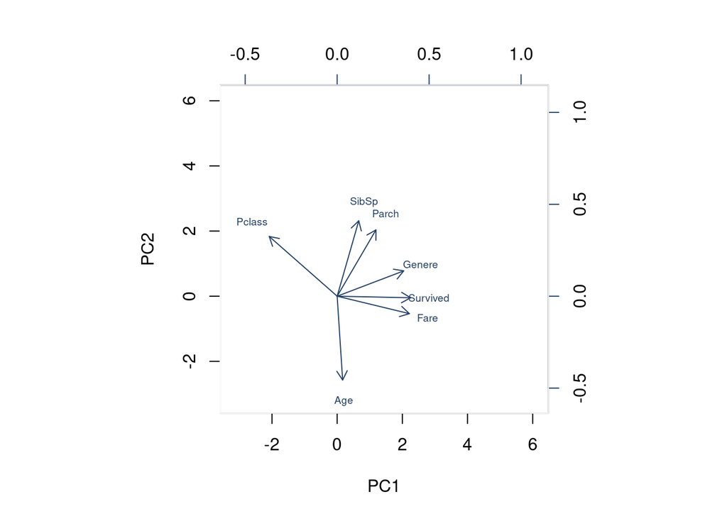

```r
# Cria o biplot das componentes principais
biplot(pca, scale = 0, cex = 0.6, col = c("white", "#254166"))
```

## Taxa de sobrevivencia de homens e mulheres

[output not shown]

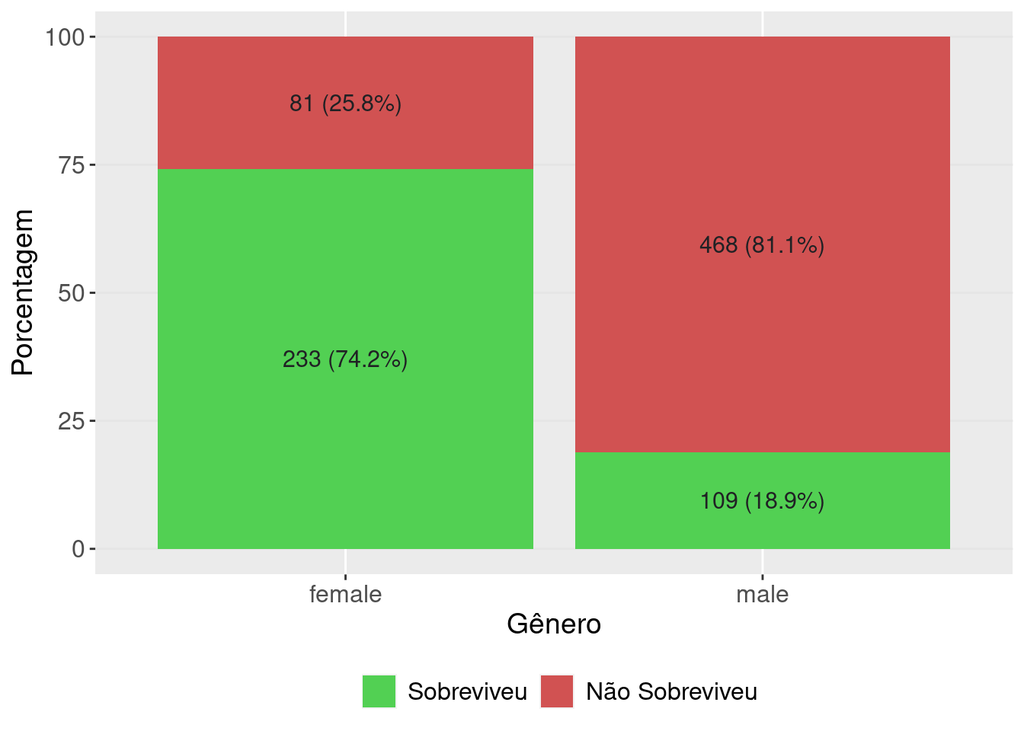

## Análise dos Salvos e Mortos no Titanic

> Começando pela análise da distribuição da faixa etária

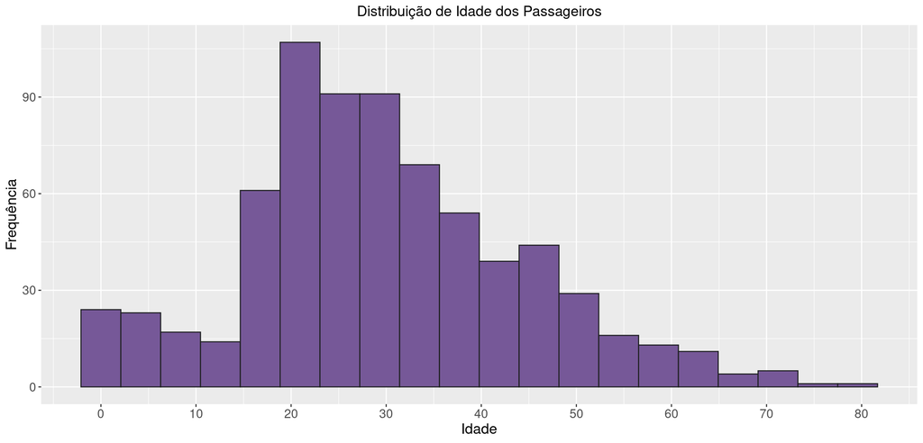

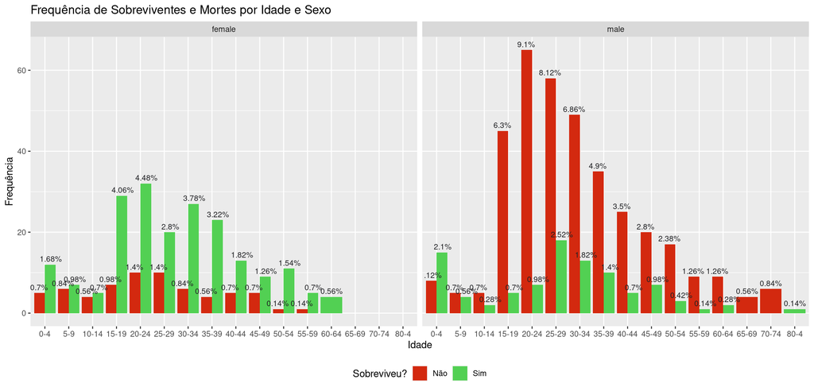

### Análise das Classes e sua Influência

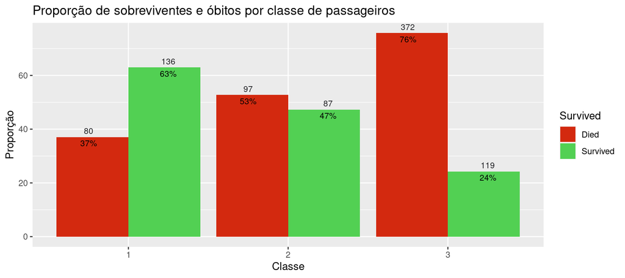

> **Visualizando a Proporção de Cada Classe ao Total**

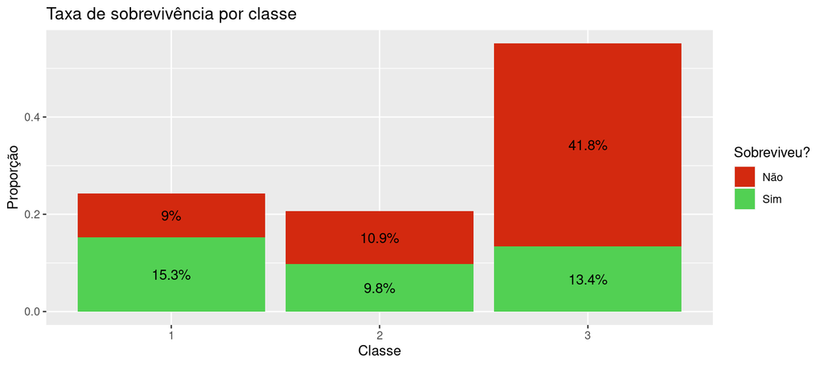

> **Análise sobre os mesmos Níveis**

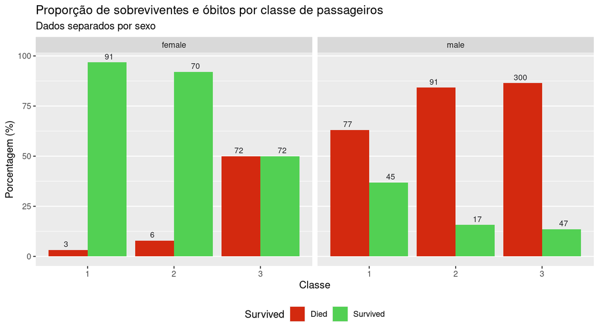

> **Separação do Gênero e sua Proporção ao Todo**

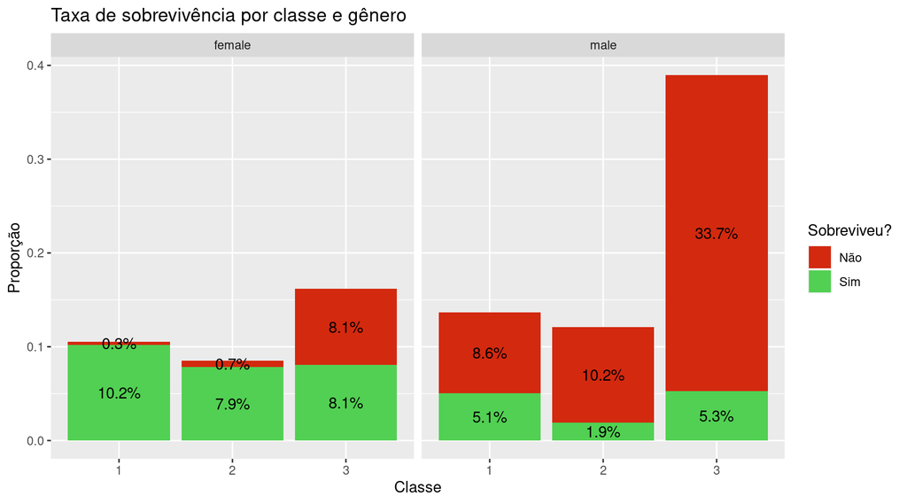

## Probabilidade de sobrevivencia

> **Fotores que influencia na sobrevivencia**

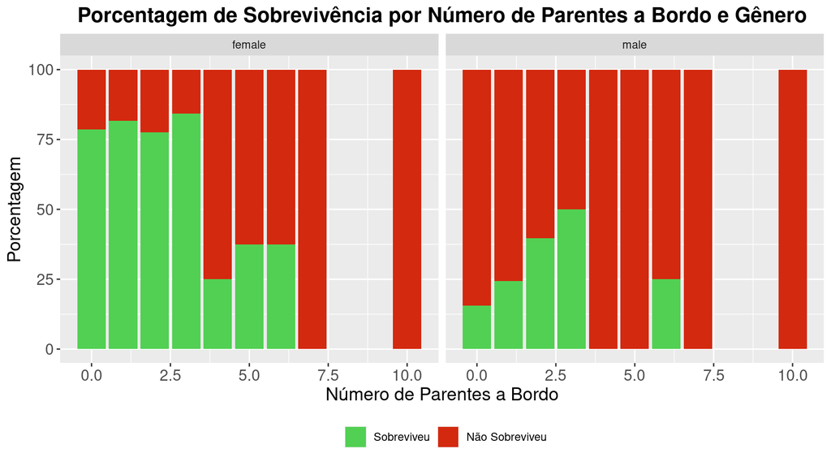

## Análise das Colunas `SibSp` e `Parch`

> **As variáveis SibSp e Parch no conjunto de dados Titanic representam informações diferentes.

A variável SibSp representa o número de irmãos/cônjuges a bordo do navio, enquanto a variável Parch representa o número de pais/filhos a bordo do navio. Portanto, são informações distintas e podem ser utilizadas de formas diferentes em análises.**

#### Pode excluir (Se quiser)

```
## , ,  = 0
##
##
##       0   1   2   3   4   5   6
##   0 374  13   8   0   1   2   0
##   1  59  23   7   2   3   2   1
##   2  12   1   2   0   0   0   0
##   3   0   7   5   0   0   0   0
##   4   0   9   6   0   0   0   0
##   5   0   0   5   0   0   0   0
##   8   0   0   7   0   0   0   0
##
## , ,  = 1
##
##
##       0   1   2   3   4   5   6
##   0 163  25  21   1   0   0   0
##   1  64  34  12   1   0   1   0
##   2   4   6   2   1   0   0   0
##   3   2   0   2   0   0   0   0
##   4   0   0   3   0   0   0   0
##   5   0   0   0   0   0   0   0
##   8   0   0   0   0   0   0   0
```

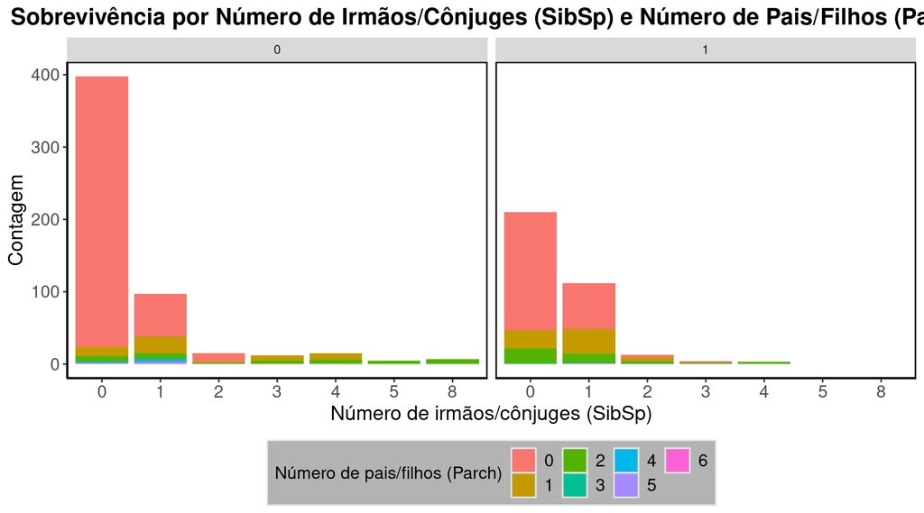

### Responsaveis pela Análise

> Fatec Data Science

### Gabriel L. S. Silva

[LinkedIn /gabrielluizone](https://www.linkedin.com/in/gabrielluizone/)

### Gabriel A. Nascimento

LinkedIn /gabriel-andrade-do-nascimento

### Fernanda

[figure not shown]

[figure not shown]

Logo da Turma Data Science